# PGS Catalog Calculator (`pgsc_calc`) report

Author

PGS Catalog Calculator (`pgsc_calc`)

Published

May 30, 2024

**Note**

See the online [documentation](https://pgsc-calc.readthedocs.io/en/latest/explanation/output.html) for additional explanation of the terms and data presented in this report.

# Workflow metadata

## Command

```bash
cat command.txt | fold -w 80 -s | awk -F ' ' 'NR==1 { print "$", $0} NR>1 { print "    " $0}' | sed 's/$/\\/' | sed '$ s/.$//'
```

```
$ nextflow run main.nf -profile docker,arm --input \
    /Users/bwingfield/Documents/data/hgdp/split/samplesheet.csv --target_build \
    GRCh38 --run_ancestry \
    /Users/bwingfield/Documents/data/refdb/pgsc_1000G_v1.tar.zst --pgs_id \
    PGS001229,PGS000882
```

## Version

```
2.0.0-alpha.5
```

# Scoring file metadata

## Scoring file summary

```r
json_list <- jsonlite::fromJSON(params$log_scorefiles, simplifyVector = FALSE)
json_scorefiles <- unlist(json_list, recursive=FALSE)

link_traits <- function(trait_efo, mapped) {
  if (length(trait_efo) == 0) {
    return("")
  } else {
    return(purrr::map2_chr(trait_efo, mapped, ~ stringr::str_glue('<a href="http://www.ebi.ac.uk/efo/{.x}">{.y}</a>')))
  }
}

extract_traits <- function(x) {
  trait_efo <- purrr::map(json_scorefiles, ~ extract_chr_handle_null(.x, "trait_efo"))
  mapped <- purrr::map(json_scorefiles, ~ extract_chr_handle_null(.x, "trait_mapped"))
  trait_display <- purrr::map2(trait_efo, mapped, link_traits)
  mapped_trait_links <- purrr::map_chr(trait_display, ~ paste(.x, collapse = "<br />"))
  reported_traits <- purrr::map(json_scorefiles, ~ extract_chr_handle_null(.x, "trait_reported"))
  purrr::map2(reported_traits, mapped_trait_links, ~ {
    stringr::str_glue("<u>Reported trait:</u> {.x} <br /> <u>Mapped trait(s):</u> {.y}")
  })
}

extract_chr_handle_null <- function(x, field) {
  return(replace(x[[field]], is.null(x[[field]]), ""))
}

link_pgscatalog <- function(id, link_type) {
  if (id != "") {
    return(stringr::str_glue('<a href="https://www.pgscatalog.org/{link_type}/{id}">{id}</a>'))
  } else {
    return(id)
  }
}

add_note <- function(id, note) {
  if (id != "") {
    return(stringr::str_glue("{id} <br /> <small>{note}</small>"))
  } else {
    return(id)
  }
}

annotate_genome_build <- function(original_build, harmonised_build) {
  return(stringr::str_glue("<u>Original build:</u> {original_build} <br /> <u>Harmonised build:</u> {harmonised_build}"))
}

tibble::tibble(json = json_scorefiles) %>%
  # extract fields from json list
  mutate(pgs_id = purrr::map_chr(json, ~ extract_chr_handle_null(.x, "pgs_id")),
         pgs_name = purrr::map_chr(json, ~ extract_chr_handle_null(.x, "pgs_name")),
         pgp_id = purrr::map_chr(json, ~ extract_chr_handle_null(.x, "pgp_id")),
         citation = purrr::map_chr(json, ~ extract_chr_handle_null(.x, "citation")),
         # trait_efo = purrr::map_chr(json, ~ extract_chr_handle_null(.x, "trait_efo")),
         # trait_reported = purrr::map_chr(json, ~ extract_chr_handle_null(.x, "trait_reported")),
         # trait_mapped = purrr::map_chr(json, ~ extract_chr_handle_null(.x, "trait_mapped")),
         trait_display = extract_traits(.),
         genome_build = purrr::map_chr(json, ~ extract_chr_handle_null(.x, "genome_build")),
         harmonised_build = purrr::map_chr(json, ~ extract_chr_handle_null(.x, "HmPOS_build")),
         n_variants = purrr::map_chr(json, ~ .x$variants_number),
         accession = stringr::str_replace_all(names(json), "_", " ")
         ) %>%
  # add links to pgs catalog identifiers
  mutate(pgs_id = purrr::map_chr(pgs_id, ~ link_pgscatalog(.x, "score")),
         pgp_id = purrr::map_chr(pgp_id, ~ link_pgscatalog(.x, "publication"))) %>%
  # add notes
  mutate(pgp_id = purrr::map2_chr(pgp_id, citation, ~ add_note(.x, .y)),
         pgs_id = purrr::map2_chr(pgs_id, pgs_name, ~ add_note(.x, .y)),
         genome_build = purrr::map2_chr(genome_build, harmonised_build, ~ annotate_genome_build(.x, .y))) %>%
  # pick columns
  select(accession, pgs_id, pgp_id, trait_display, n_variants, genome_build) -> scorefile_metadata
```

| Scoring file | Polygenic Score ID | Publication | Traits | Number of variants | Genome build |
| --- | --- | --- | --- | --- | --- |
| PGS000882 hmPOS GRCh38 | PGS000882 25OHD_SBayesR_PGS | PGP000228 Revez JA et al. Nat Commun (2020). doi:10.1038/s41467-020-15421-7 | ['Reported trait: 25-hydroxyvitamin D Mapped trait(s): vitamin D measurement'] | 1094650 | Original build: GRCh37 Harmonised build: GRCh38 |
| PGS001229 hmPOS GRCh38 | PGS001229 GBE_INI50 | PGP000244 Tanigawa Y et al. PLoS Genet (2022). doi:10.1371/journal.pgen.1010105 | ['Reported trait: Standing height Mapped trait(s): body height'] | 51209 | Original build: GRCh37 Harmonised build: GRCh38 |

# Variant matching

## Parameters

```bash
cat params.txt
```

```
keep_multiallelic: false
keep_ambiguous   : false
min_overlap      : 0.75
```

## Reference matching summary

|  | reference | n target | N variants in panel | n (matched) | % matched |
| --- | --- | --- | --- | --- | --- |
| 1 | 1000G | 83718720 | 73427307 | 40510256 | 55.17 |

## Summary

```r
log_df %>%
  mutate(match_status = forcats::fct_collapse(match_status, matched = "matched", other_level = "unmatched")) %>%
  group_by(sampleset, accession, match_status, score_pass) %>%
  count(wt = count) %>%
  group_by(sampleset, accession) %>%
  mutate(percent = round(n / sum(n) * 100, 1), n_variants = sum(n)) %>%
  arrange(accession, desc(percent)) %>%
  tidyr::pivot_wider(names_from = match_status, values_from = c(n, percent)) %>%
  replace(is.na(.), 0) -> compat
```

```r
if (!"n_unmatched" %in% colnames(compat)) {
  # handle missing column if all PGS matches perfectly (e.g. no unmatched or excluded variants)
  compat <- compat %>%
    mutate(n_unmatched = 0)
}

compat %>%
  select(sampleset, accession, n_variants, score_pass, percent_matched,
         n_matched, n_unmatched) %>%
  mutate(score_pass = as.logical(score_pass)) %>%
  DT::datatable(rownames = FALSE,
                extensions = 'Buttons',
    options = list(dom = 'Bfrtip',
                   buttons = c('csv')),
    colnames = c(
      "Sampleset" = "sampleset",
      "Scoring file" = "accession",
      "Number of variants" = "n_variants",
      "Passed matching" = "score_pass",
      "Match %" = "percent_matched",
      "Total matched" = "n_matched",
      "Total unmatched" = "n_unmatched"
    )) %>%
  DT::formatStyle('Scoring file',
                  valueColumns = 'Passed matching',
                  backgroundColor = DT::styleEqual(c(FALSE, TRUE), c('#c2a5cf', '#a6dba0')))
```

| Sampleset | Scoring file | Number of variants | Passed matching | Match % | Total matched | Total unmatched |
| --- | --- | --- | --- | --- | --- | --- |
| hgdp | PGS000882_hmPOS_GRCh38 | 1094650 | True | 91 | 995728 | 98922 |
| hgdp | PGS001229_hmPOS_GRCh38 | 51209 | True | 91.3 | 46778 | 4431 |

## Detailed log

| Sampleset | Scoring file | Match type | Variant in reference panel | Ambiguous | Multiallelic | Matches strand flip | Multiple potential matches | Duplicated matched variants | n | % |
| --- | --- | --- | --- | --- | --- | --- | --- | --- | --- | --- |
| hgdp | PGS000882 hmPOS GRCh38 | matched | true | false | false | false | false | false | 995176 | 90.91 |
| hgdp | PGS000882 hmPOS GRCh38 | matched | true | false | false | true | false | false | 552 | 0.05 |
| hgdp | PGS000882 hmPOS GRCh38 | excluded | false | false | false | false | false | false | 1052 | 0.1 |
| hgdp | PGS000882 hmPOS GRCh38 | excluded | false | false | false | true | false | false | 4 | 0 |
| hgdp | PGS000882 hmPOS GRCh38 | excluded | false | false | true | false | true | false | 34 | 0 |
| hgdp | PGS000882 hmPOS GRCh38 | excluded | false | false | true | true | true | false | 1 | 0 |
| hgdp | PGS000882 hmPOS GRCh38 | excluded | false | true | false | false | false | false | 80 | 0.01 |
| hgdp | PGS000882 hmPOS GRCh38 | excluded | false | true | true | false | true | false | 3 | 0 |
| hgdp | PGS000882 hmPOS GRCh38 | excluded | true | false | true | false | true | false | 12031 | 1.1 |
| hgdp | PGS000882 hmPOS GRCh38 | excluded | true | false | true | true | true | false | 3 | 0 |

[output cut: 13 more lines]

# Genetic Ancestry

```
# A tibble: 6 × 22
  sampleset IID         PC1   PC2   PC3    PC4    PC5   PC6    PC7    PC8    PC9
  <chr>     <chr>     <dbl> <dbl> <dbl>  <dbl>  <dbl> <dbl>  <dbl>  <dbl>  <dbl>
1 hgdp      HGDP00001 -18.5 -31.2 -19.7 -2.40  -0.761  5.61  0.973  1.34   2.56
2 hgdp      HGDP00003 -18.8 -29.9 -20.7 -0.866 -0.304  7.31 -0.186  0.350  5.56
3 hgdp      HGDP00005 -18.4 -29.7 -19.1 -4.00  -2.59   5.66  2.67   1.62  -0.907
4 hgdp      HGDP00007 -19.1 -32.1 -23.8 -0.913 -1.43   7.88 -0.120 -1.00   2.32
5 hgdp      HGDP00009 -18.2 -30.8 -21.5 -1.09  -0.721  6.75 -0.241 -0.931  1.09
6 hgdp      HGDP00011 -20.1 -32.1 -21.9 -0.693  0.879  6.62 -0.310  1.42   2.92
# ℹ 11 more variables: PC10 <dbl>, Unrelated <lgl>, RF_P_AFR <dbl>,
#   RF_P_AMR <dbl>, RF_P_EAS <dbl>, RF_P_EUR <dbl>, RF_P_SAS <dbl>,
#   MostSimilarPop <chr>, MostSimilarPop_LowConfidence <lgl>, REFERENCE <lgl>,
#   SuperPop <chr>
```

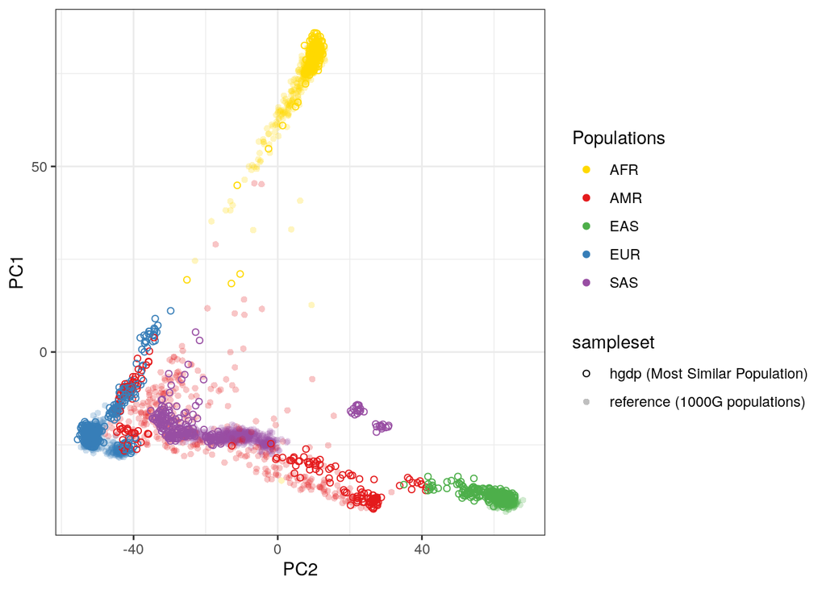

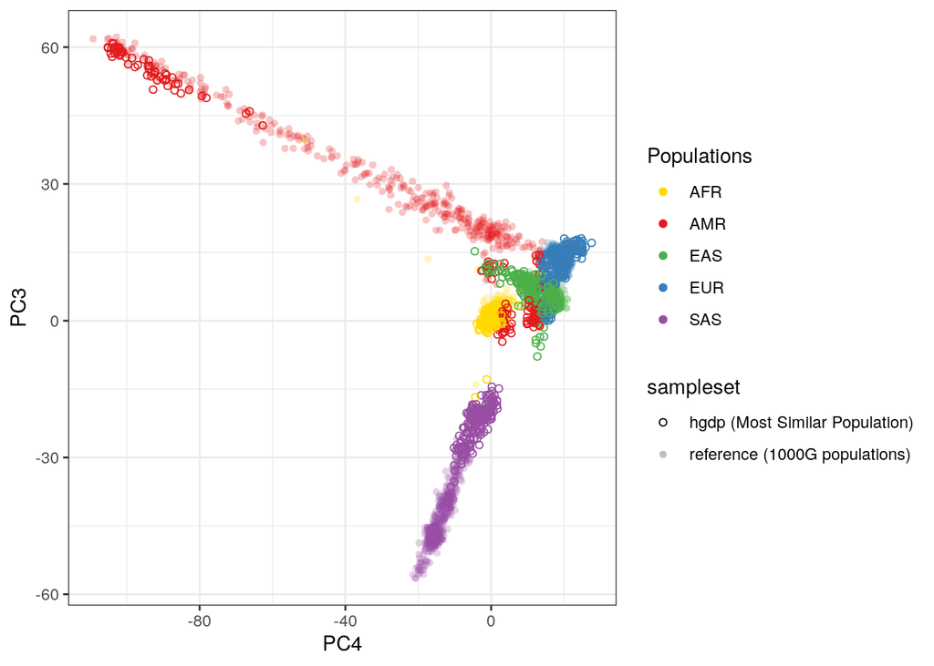

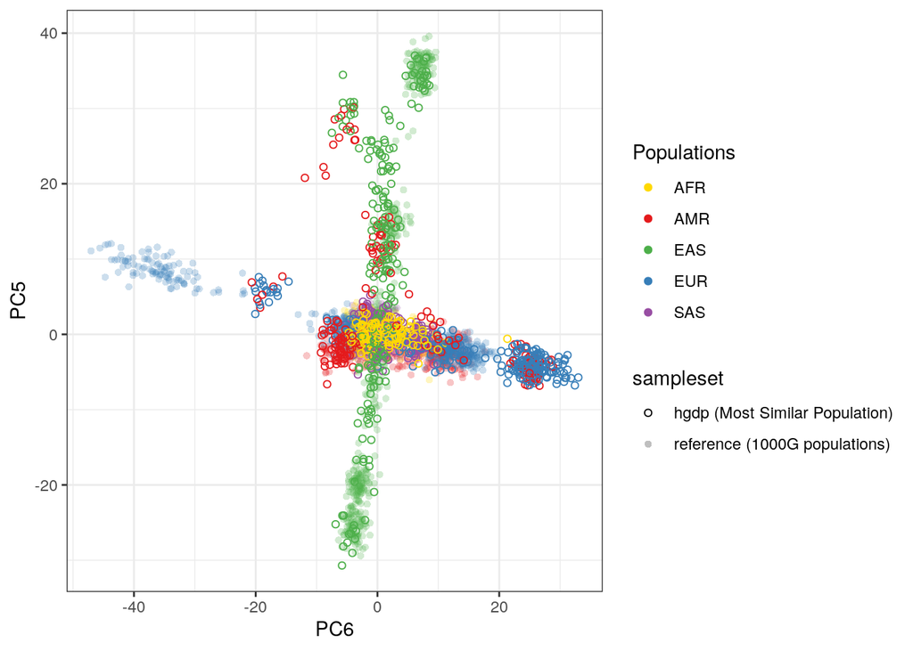

## Population similarity summary

|  | Most similar population | hgdp | reference |
| --- | --- | --- | --- |
| 1 | AFR | 110 (11.84%) | 681 (26.45%) |
| 2 | AMR | 165 (17.76%) | 351 (13.63%) |
| 3 | EAS | 209 (22.5%) | 507 (19.69%) |
| 4 | EUR | 251 (27.02%) | 525 (20.39%) |
| 5 | SAS | 194 (20.88%) | 511 (19.84%) |

# Scores

```
[1] 3504
```

**Success**

- All requested scores were calculated successfully

2 scores for 3504 samples processed.

### Score data

#### Score extract

**Note**

Below is a summary of the aggregated scores, which might be useful for debugging. See here for an explanation of [plink2](https://www.cog-genomics.org/plink/2.0/formats#sscore) column names

```
# A tibble: 7,008 × 8
   sampleset IID       PGS                  SUM Z_MostSimilarPop Z_norm1 Z_norm2
   <chr>     <chr>     <chr>              <dbl>            <dbl>   <dbl>   <dbl>
 1 hgdp      HGDP00001 PGS000882_hmPOS_… -0.546            2.05    1.57    1.49
 2 hgdp      HGDP00003 PGS000882_hmPOS_… -1.22            -0.816  -1.42   -1.34
 3 hgdp      HGDP00005 PGS000882_hmPOS_… -0.869            0.682   0.140   0.136
 4 hgdp      HGDP00007 PGS000882_hmPOS_… -0.860            0.720   0.216   0.207
 5 hgdp      HGDP00009 PGS000882_hmPOS_… -0.627            1.71    1.23    1.16
 6 hgdp      HGDP00011 PGS000882_hmPOS_… -0.764            1.13    0.615   0.582
 7 hgdp      HGDP00013 PGS000882_hmPOS_… -0.685            1.46    1.01    0.993
 8 hgdp      HGDP00015 PGS000882_hmPOS_… -0.833            0.837   0.304   0.289
 9 hgdp      HGDP00017 PGS000882_hmPOS_… -0.627            1.71    1.20    1.14
10 hgdp      HGDP00019 PGS000882_hmPOS_… -0.840            0.806   0.238   0.228
# ℹ 6,998 more rows
# ℹ 1 more variable: percentile_MostSimilarPop <dbl>
```

#### Density plot(s)

**Note**

The summary density plots show up to six scoring files

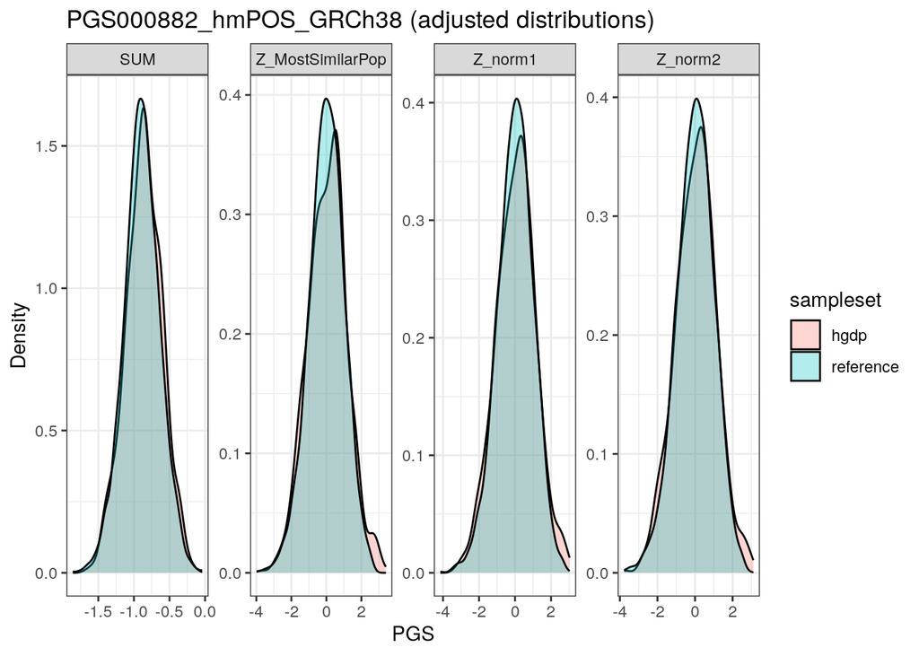

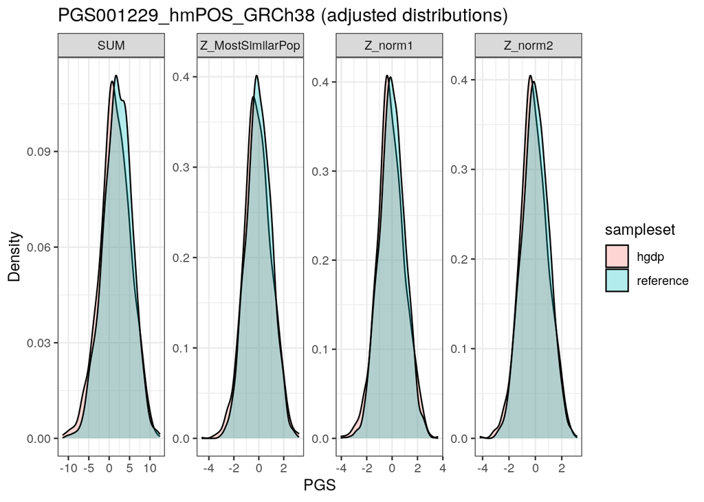

### Get all scores

All scores can be found in the results directory, at:

```
hgdp/score/hgdp_pgs.txt.gz
```

# Citations

**Important**

For scores from the PGS Catalog, please remember to cite the original publications from which they came (these are listed in the metadata table.)

> PGS Catalog Calculator (in development). PGS Catalog Team. `https://github.com/PGScatalog/pgsc_calc`

> Lambert et al. (2021) The Polygenic Score Catalog as an open database for reproducibility and systematic evaluation. Nature Genetics. 53:420–425 doi:10.1038/s41588-021-00783-5.

## Score licenses

**Tip**

- Scores deposited in the PGS Catalog may have specific license terms
- It’s important to follow the license terms when you reuse scoring files
- Please check below for a summary of license terms
- License terms for custom scoring files aren’t reported here, please check how the creators of the scoring file licensed their data

```r
# as of 2023-12-12 only non-default licenses are recorded in the scoring file header
default_ebi_terms <- "PGS obtained from the Catalog should be cited appropriately, and used in accordance with any licensing restrictions set by the authors. See EBI Terms of Use (https://www.ebi.ac.uk/about/terms-of-use/) for additional details."

tibble::tibble(json = json_scorefiles) %>%
  mutate(pgs_id = purrr::map_chr(json, ~ extract_chr_handle_null(.x, "pgs_id")),
         license_text = purrr::map_chr(json, ~ extract_chr_handle_null(.x, "license"))) %>%
  mutate(license_text = ifelse(license_text == "", default_ebi_terms, license_text)) %>%
  # display license terms for files in the PGS Catalog only (with a PGS ID)
  filter(startsWith(pgs_id, "PGS")) %>%
  select(-json) %>%
  DT::datatable(., colnames = c(
      "PGS ID" = "pgs_id",
      "License text" = "license_text"
    ))
```

|  | PGS ID | License text |
| --- | --- | --- |
| 1 | PGS000882 | PGS obtained from the Catalog should be cited appropriately, and used in accordance with any licensing restrictions set by the authors. See EBI Terms of Use (https://www.ebi.ac.uk/about/terms-of-use/)… |
| 2 | PGS001229 | PGS obtained from the Catalog should be cited appropriately, and used in accordance with any licensing restrictions set by the authors. See EBI Terms of Use (https://www.ebi.ac.uk/about/terms-of-use/)… |